# Risk Factor Analysis

## Outcome Variable

**Outcome Variable:** y_rate_len

## Predictor Variables

**Intervention Variable:** hfoodsec

**Adjustment Set:**

- arm
- sex
- W_mage
- meducyrs
- feducyrs
- hhwealth_quart
- vagbrth
- W_nrooms
- W_nchldlt5
- brthmon
- W_parity
- impfloor
- impsan
- safeh20
- delta_W_mage
- delta_meducyrs
- delta_feducyrs
- delta_hhwealth_quart
- delta_vagbrth
- delta_W_nrooms
- delta_W_nchldlt5
- delta_brthmon
- delta_W_parity
- delta_impfloor
- delta_impsan
- delta_safeh20

## Stratifying Variables

The analysis was stratified on these variable(s):

- agecat
- studyid
- country

## Data Summary

| agecat | studyid | country | hfoodsec | n_cell | n |
| --- | --- | --- | --- | --- | --- |
| 0-3 months | ki0047075b-MAL-ED | BANGLADESH | Food Secure | 160 | 192 |
| 0-3 months | ki0047075b-MAL-ED | BANGLADESH | Mildly Food Insecure | 4 | 192 |
| 0-3 months | ki0047075b-MAL-ED | BANGLADESH | Moderately Food Insecure | 22 | 192 |
| 0-3 months | ki0047075b-MAL-ED | BANGLADESH | Severely Food Insecure | 6 | 192 |
| 0-3 months | ki1017093-NIH-Birth | BANGLADESH | Food Secure | 83 | 566 |
| 0-3 months | ki1017093-NIH-Birth | BANGLADESH | Mildly Food Insecure | 444 | 566 |
| 0-3 months | ki1017093-NIH-Birth | BANGLADESH | Moderately Food Insecure | 34 | 566 |
| 0-3 months | ki1017093-NIH-Birth | BANGLADESH | Severely Food Insecure | 5 | 566 |
| 0-3 months | ki1017093c-NIH-Crypto | BANGLADESH | Food Secure | 427 | 720 |
| 0-3 months | ki1017093c-NIH-Crypto | BANGLADESH | Mildly Food Insecure | 207 | 720 |
| 0-3 months | ki1017093c-NIH-Crypto | BANGLADESH | Moderately Food Insecure | 62 | 720 |
| 0-3 months | ki1017093c-NIH-Crypto | BANGLADESH | Severely Food Insecure | 24 | 720 |
| 0-3 months | kiGH5241-JiVitA-3 | BANGLADESH | Food Secure | 6496 | 13158 |
| 0-3 months | kiGH5241-JiVitA-3 | BANGLADESH | Mildly Food Insecure | 4424 | 13158 |
| 0-3 months | kiGH5241-JiVitA-3 | BANGLADESH | Moderately Food Insecure | 2238 | 13158 |
| 0-3 months | kiGH5241-JiVitA-4 | BANGLADESH | Food Secure | 914 | 1796 |
| 0-3 months | kiGH5241-JiVitA-4 | BANGLADESH | Mildly Food Insecure | 634 | 1796 |
| 0-3 months | kiGH5241-JiVitA-4 | BANGLADESH | Moderately Food Insecure | 248 | 1796 |
| 0-3 months | ki0047075b-MAL-ED | BRAZIL | Mildly Food Insecure | 11 | 105 |
| 0-3 months | ki0047075b-MAL-ED | BRAZIL | Moderately Food Insecure | 54 | 105 |
| 0-3 months | ki0047075b-MAL-ED | BRAZIL | Severely Food Insecure | 40 | 105 |
| 0-3 months | ki0047075b-MAL-ED | INDIA | Food Secure | 157 | 173 |
| 0-3 months | ki0047075b-MAL-ED | INDIA | Mildly Food Insecure | 2 | 173 |
| 0-3 months | ki0047075b-MAL-ED | INDIA | Moderately Food Insecure | 3 | 173 |
| 0-3 months | ki0047075b-MAL-ED | INDIA | Severely Food Insecure | 11 | 173 |
| 0-3 months | ki0047075b-MAL-ED | NEPAL | Food Secure | 77 | 100 |
| 0-3 months | ki0047075b-MAL-ED | NEPAL | Mildly Food Insecure | 9 | 100 |
| 0-3 months | ki0047075b-MAL-ED | NEPAL | Moderately Food Insecure | 11 | 100 |
| 0-3 months | ki0047075b-MAL-ED | NEPAL | Severely Food Insecure | 3 | 100 |
| 0-3 months | ki0047075b-MAL-ED | PERU | Food Secure | 27 | 107 |

[output cut: 133 more lines]

The following strata were considered:

- agecat: 0-3 months, studyid: ki0047075b-MAL-ED, country: BANGLADESH
- agecat: 0-3 months, studyid: ki0047075b-MAL-ED, country: BRAZIL
- agecat: 0-3 months, studyid: ki0047075b-MAL-ED, country: INDIA
- agecat: 0-3 months, studyid: ki0047075b-MAL-ED, country: NEPAL
- agecat: 0-3 months, studyid: ki0047075b-MAL-ED, country: PERU
- agecat: 0-3 months, studyid: ki0047075b-MAL-ED, country: SOUTH AFRICA
- agecat: 0-3 months, studyid: ki1017093-NIH-Birth, country: BANGLADESH
- agecat: 0-3 months, studyid: ki1017093c-NIH-Crypto, country: BANGLADESH
- agecat: 0-3 months, studyid: kiGH5241-JiVitA-3, country: BANGLADESH
- agecat: 0-3 months, studyid: kiGH5241-JiVitA-4, country: BANGLADESH
- agecat: 12-24 months, studyid: ki0047075b-MAL-ED, country: BANGLADESH
- agecat: 12-24 months, studyid: ki0047075b-MAL-ED, country: BRAZIL
- agecat: 12-24 months, studyid: ki0047075b-MAL-ED, country: INDIA
- agecat: 12-24 months, studyid: ki0047075b-MAL-ED, country: NEPAL
- agecat: 12-24 months, studyid: ki0047075b-MAL-ED, country: PERU
- agecat: 12-24 months, studyid: ki0047075b-MAL-ED, country: SOUTH AFRICA
- agecat: 12-24 months, studyid: ki1017093-NIH-Birth, country: BANGLADESH
- agecat: 12-24 months, studyid: ki1017093c-NIH-Crypto, country: BANGLADESH
- agecat: 12-24 months, studyid: ki1113344-GMS-Nepal, country: NEPAL
- agecat: 12-24 months, studyid: kiGH5241-JiVitA-3, country: BANGLADESH
- agecat: 12-24 months, studyid: kiGH5241-JiVitA-4, country: BANGLADESH
- agecat: 3-6 months, studyid: ki0047075b-MAL-ED, country: BANGLADESH
- agecat: 3-6 months, studyid: ki0047075b-MAL-ED, country: BRAZIL
- agecat: 3-6 months, studyid: ki0047075b-MAL-ED, country: INDIA
- agecat: 3-6 months, studyid: ki0047075b-MAL-ED, country: NEPAL
- agecat: 3-6 months, studyid: ki0047075b-MAL-ED, country: PERU
- agecat: 3-6 months, studyid: ki0047075b-MAL-ED, country: SOUTH AFRICA
- agecat: 3-6 months, studyid: ki1017093-NIH-Birth, country: BANGLADESH
- agecat: 3-6 months, studyid: ki1017093c-NIH-Crypto, country: BANGLADESH
- agecat: 3-6 months, studyid: ki1113344-GMS-Nepal, country: NEPAL
- agecat: 3-6 months, studyid: kiGH5241-JiVitA-3, country: BANGLADESH
- agecat: 3-6 months, studyid: kiGH5241-JiVitA-4, country: BANGLADESH
- agecat: 6-12 months, studyid: ki0047075b-MAL-ED, country: BANGLADESH
- agecat: 6-12 months, studyid: ki0047075b-MAL-ED, country: BRAZIL
- agecat: 6-12 months, studyid: ki0047075b-MAL-ED, country: INDIA
- agecat: 6-12 months, studyid: ki0047075b-MAL-ED, country: NEPAL
- agecat: 6-12 months, studyid: ki0047075b-MAL-ED, country: PERU
- agecat: 6-12 months, studyid: ki0047075b-MAL-ED, country: SOUTH AFRICA
- agecat: 6-12 months, studyid: ki1017093-NIH-Birth, country: BANGLADESH
- agecat: 6-12 months, studyid: ki1017093c-NIH-Crypto, country: BANGLADESH
- agecat: 6-12 months, studyid: ki1113344-GMS-Nepal, country: NEPAL
- agecat: 6-12 months, studyid: kiGH5241-JiVitA-3, country: BANGLADESH
- agecat: 6-12 months, studyid: kiGH5241-JiVitA-4, country: BANGLADESH

### Dropped Strata

Some strata were dropped due to rare outcomes:

- agecat: 0-3 months, studyid: ki0047075b-MAL-ED, country: BANGLADESH
- agecat: 0-3 months, studyid: ki0047075b-MAL-ED, country: INDIA
- agecat: 0-3 months, studyid: ki0047075b-MAL-ED, country: NEPAL
- agecat: 3-6 months, studyid: ki0047075b-MAL-ED, country: BANGLADESH
- agecat: 3-6 months, studyid: ki1017093-NIH-Birth, country: BANGLADESH
- agecat: 3-6 months, studyid: ki0047075b-MAL-ED, country: BRAZIL
- agecat: 3-6 months, studyid: ki0047075b-MAL-ED, country: INDIA
- agecat: 3-6 months, studyid: ki0047075b-MAL-ED, country: NEPAL
- agecat: 6-12 months, studyid: ki0047075b-MAL-ED, country: BANGLADESH
- agecat: 6-12 months, studyid: ki1017093-NIH-Birth, country: BANGLADESH
- agecat: 6-12 months, studyid: ki0047075b-MAL-ED, country: BRAZIL
- agecat: 6-12 months, studyid: ki0047075b-MAL-ED, country: INDIA
- agecat: 6-12 months, studyid: ki0047075b-MAL-ED, country: NEPAL
- agecat: 12-24 months, studyid: ki0047075b-MAL-ED, country: BANGLADESH
- agecat: 12-24 months, studyid: ki1017093-NIH-Birth, country: BANGLADESH
- agecat: 12-24 months, studyid: ki0047075b-MAL-ED, country: BRAZIL
- agecat: 12-24 months, studyid: ki0047075b-MAL-ED, country: INDIA
- agecat: 12-24 months, studyid: ki0047075b-MAL-ED, country: NEPAL

## Methods Detail

We’re interested in the causal parameters $E[Y_a]$ for all values of $a \in \mathcal{A}$. These parameters represent the mean outcome if, possibly contrary to fact, we intervened to set all units to have $A=a$. Under the randomization and positivity assumptions, these are identified by the statistical parameters $\psi_a=E_W[E_{Y|A,W}(Y|A=a,W)]$. In addition, we’re interested in the mean of $Y$, $E[Y]$ under no intervention (the observed mean). We will estimate these parameters by using SuperLearner to fit the relevant likelihood factors – $E_{Y|A,W}(Y|A=a,W)$ and $p(A=a|W)$, and then updating our likelihood fit using a joint TMLE.

For unadjusted analyses ($W=\{\}$), initial likelihoods were estimated using Lrnr_glm to estimate the simple $E(Y|A)$ and Lrnr_mean to estimate $p(A)$. For adjusted analyses, a small library containing Lrnr_glmnet, Lrnr_xgboost, and Lrnr_mean was used.

Having estimated these parameters, we will then use the delta method to estimate relative risks and attributable risks relative to a prespecified baseline level of $A$.

[output not shown]

[output not shown]

[output not shown]

[output not shown]

[output not shown]

[output not shown]

[output not shown]

[output not shown]

[output not shown]

# Results Detail

## Results Plots

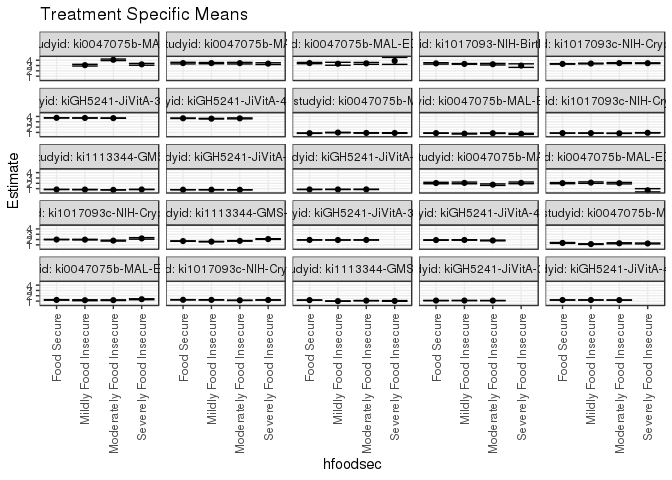

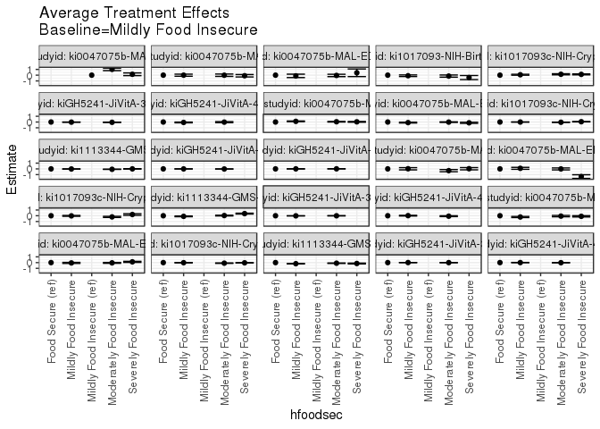

## Results Table

### Parameter: TSM

| agecat | studyid | country | intervention_level | baseline_level | estimate | ci_lower | ci_upper |
| --- | --- | --- | --- | --- | --- | --- | --- |
| 0-3 months | ki0047075b-MAL-ED | BRAZIL | Mildly Food Insecure | NA | 3.0689887 | 2.9047276 | 3.2332497 |
| 0-3 months | ki0047075b-MAL-ED | BRAZIL | Moderately Food Insecure | NA | 4.0755873 | 3.9280819 | 4.2230926 |
| 0-3 months | ki0047075b-MAL-ED | BRAZIL | Severely Food Insecure | NA | 3.2240290 | 3.0576065 | 3.3904516 |
| 0-3 months | ki0047075b-MAL-ED | PERU | Food Secure | NA | 3.4559755 | 3.3092317 | 3.6027192 |
| 0-3 months | ki0047075b-MAL-ED | PERU | Mildly Food Insecure | NA | 3.4530664 | 3.3352113 | 3.5709216 |
| 0-3 months | ki0047075b-MAL-ED | PERU | Moderately Food Insecure | NA | 3.4462946 | 3.2988859 | 3.5937032 |
| 0-3 months | ki0047075b-MAL-ED | PERU | Severely Food Insecure | NA | 3.3533843 | 3.1901072 | 3.5166613 |
| 0-3 months | ki0047075b-MAL-ED | SOUTH AFRICA | Food Secure | NA | 3.4581198 | 3.3427256 | 3.5735140 |
| 0-3 months | ki0047075b-MAL-ED | SOUTH AFRICA | Mildly Food Insecure | NA | 3.3321771 | 3.0574601 | 3.6068942 |
| 0-3 months | ki0047075b-MAL-ED | SOUTH AFRICA | Moderately Food Insecure | NA | 3.4072717 | 3.2313124 | 3.5832311 |
| 0-3 months | ki0047075b-MAL-ED | SOUTH AFRICA | Severely Food Insecure | NA | 3.8707918 | 3.2160322 | 4.5255514 |
| 0-3 months | ki1017093-NIH-Birth | BANGLADESH | Food Secure | NA | 3.4027950 | 3.2748489 | 3.5307410 |
| 0-3 months | ki1017093-NIH-Birth | BANGLADESH | Mildly Food Insecure | NA | 3.3033958 | 3.2420770 | 3.3647146 |
| 0-3 months | ki1017093-NIH-Birth | BANGLADESH | Moderately Food Insecure | NA | 3.2450368 | 3.1025957 | 3.3874779 |
| 0-3 months | ki1017093-NIH-Birth | BANGLADESH | Severely Food Insecure | NA | 2.9880303 | 2.6571058 | 3.3189548 |
| 0-3 months | ki1017093c-NIH-Crypto | BANGLADESH | Food Secure | NA | 3.3030395 | 3.2534967 | 3.3525823 |
| 0-3 months | ki1017093c-NIH-Crypto | BANGLADESH | Mildly Food Insecure | NA | 3.3732308 | 3.3056176 | 3.4408439 |
| 0-3 months | ki1017093c-NIH-Crypto | BANGLADESH | Moderately Food Insecure | NA | 3.4550502 | 3.3705460 | 3.5395544 |
| 0-3 months | ki1017093c-NIH-Crypto | BANGLADESH | Severely Food Insecure | NA | 3.4393925 | 3.3748282 | 3.5039569 |
| 0-3 months | kiGH5241-JiVitA-3 | BANGLADESH | Food Secure | NA | 3.7329218 | 3.7177555 | 3.7480881 |
| 0-3 months | kiGH5241-JiVitA-3 | BANGLADESH | Mildly Food Insecure | NA | 3.7118092 | 3.6937479 | 3.7298705 |
| 0-3 months | kiGH5241-JiVitA-3 | BANGLADESH | Moderately Food Insecure | NA | 3.6811024 | 3.6527839 | 3.7094210 |
| 0-3 months | kiGH5241-JiVitA-4 | BANGLADESH | Food Secure | NA | 3.6552657 | 3.6104267 | 3.7001047 |
| 0-3 months | kiGH5241-JiVitA-4 | BANGLADESH | Mildly Food Insecure | NA | 3.5817661 | 3.5320055 | 3.6315267 |
| 0-3 months | kiGH5241-JiVitA-4 | BANGLADESH | Moderately Food Insecure | NA | 3.6359574 | 3.5519672 | 3.7199477 |
| 3-6 months | ki0047075b-MAL-ED | PERU | Food Secure | NA | 2.0538879 | 1.9202705 | 2.1875052 |
| 3-6 months | ki0047075b-MAL-ED | PERU | Mildly Food Insecure | NA | 2.0748218 | 1.9217962 | 2.2278475 |
| 3-6 months | ki0047075b-MAL-ED | PERU | Moderately Food Insecure | NA | 1.7465120 | 1.6053805 | 1.8876435 |
| 3-6 months | ki0047075b-MAL-ED | PERU | Severely Food Insecure | NA | 2.0821395 | 1.9261256 | 2.2381534 |
| 3-6 months | ki0047075b-MAL-ED | SOUTH AFRICA | Food Secure | NA | 2.0352044 | 1.9298016 | 2.1406073 |

[output cut: 61 more lines]

### Parameter: E(Y)

| agecat | studyid | country | intervention_level | baseline_level | estimate | ci_lower | ci_upper |
| --- | --- | --- | --- | --- | --- | --- | --- |
| 0-3 months | ki0047075b-MAL-ED | BRAZIL | NA | NA | 4.0175394 | 3.8869881 | 4.1480907 |
| 0-3 months | ki0047075b-MAL-ED | PERU | NA | NA | 3.3547253 | 3.2634611 | 3.4459896 |
| 0-3 months | ki0047075b-MAL-ED | SOUTH AFRICA | NA | NA | 3.4411414 | 3.3443437 | 3.5379390 |
| 0-3 months | ki1017093-NIH-Birth | BANGLADESH | NA | NA | 3.3129255 | 3.2581305 | 3.3677204 |
| 0-3 months | ki1017093c-NIH-Crypto | BANGLADESH | NA | NA | 3.3028656 | 3.2646714 | 3.3410598 |
| 0-3 months | kiGH5241-JiVitA-3 | BANGLADESH | NA | NA | 3.7183193 | 3.7063844 | 3.7302541 |
| 0-3 months | kiGH5241-JiVitA-4 | BANGLADESH | NA | NA | 3.6391263 | 3.6075490 | 3.6707036 |
| 3-6 months | ki0047075b-MAL-ED | PERU | NA | NA | 1.9530249 | 1.8522017 | 2.0538480 |
| 3-6 months | ki0047075b-MAL-ED | SOUTH AFRICA | NA | NA | 1.9716570 | 1.8866692 | 2.0566449 |
| 3-6 months | ki1017093c-NIH-Crypto | BANGLADESH | NA | NA | 2.0057973 | 1.9693775 | 2.0422170 |
| 3-6 months | ki1113344-GMS-Nepal | NEPAL | NA | NA | 1.7061500 | 1.6667551 | 1.7455449 |
| 3-6 months | kiGH5241-JiVitA-3 | BANGLADESH | NA | NA | 1.9201098 | 1.9096479 | 1.9305717 |
| 3-6 months | kiGH5241-JiVitA-4 | BANGLADESH | NA | NA | 1.8993572 | 1.8693950 | 1.9293194 |
| 6-12 months | ki0047075b-MAL-ED | PERU | NA | NA | 1.1824866 | 1.1320801 | 1.2328932 |
| 6-12 months | ki0047075b-MAL-ED | SOUTH AFRICA | NA | NA | 1.1940035 | 1.1512681 | 1.2367388 |
| 6-12 months | ki1017093c-NIH-Crypto | BANGLADESH | NA | NA | 1.2281313 | 1.2106849 | 1.2455776 |
| 6-12 months | ki1113344-GMS-Nepal | NEPAL | NA | NA | 1.1725665 | 1.1528638 | 1.1922692 |
| 6-12 months | kiGH5241-JiVitA-3 | BANGLADESH | NA | NA | 1.1069878 | 1.1002423 | 1.1137334 |
| 6-12 months | kiGH5241-JiVitA-4 | BANGLADESH | NA | NA | 1.2029754 | 1.1926285 | 1.2133223 |
| 12-24 months | ki0047075b-MAL-ED | PERU | NA | NA | 0.8709334 | 0.8403674 | 0.9014995 |
| 12-24 months | ki0047075b-MAL-ED | SOUTH AFRICA | NA | NA | 0.8714362 | 0.8487736 | 0.8940987 |
| 12-24 months | ki1017093c-NIH-Crypto | BANGLADESH | NA | NA | 0.8755729 | 0.8637860 | 0.8873598 |
| 12-24 months | ki1113344-GMS-Nepal | NEPAL | NA | NA | 0.8385573 | 0.8230446 | 0.8540700 |
| 12-24 months | kiGH5241-JiVitA-3 | BANGLADESH | NA | NA | 0.7968476 | 0.7915393 | 0.8021560 |
| 12-24 months | kiGH5241-JiVitA-4 | BANGLADESH | NA | NA | 0.8495388 | 0.8441127 | 0.8549650 |

### Parameter: ATE

| agecat | studyid | country | intervention_level | baseline_level | estimate | ci_lower | ci_upper |
| --- | --- | --- | --- | --- | --- | --- | --- |
| 0-3 months | ki0047075b-MAL-ED | BRAZIL | Mildly Food Insecure | Mildly Food Insecure | 0.0000000 | 0.0000000 | 0.0000000 |
| 0-3 months | ki0047075b-MAL-ED | BRAZIL | Moderately Food Insecure | Mildly Food Insecure | 1.0065986 | 0.7916606 | 1.2215366 |
| 0-3 months | ki0047075b-MAL-ED | BRAZIL | Severely Food Insecure | Mildly Food Insecure | 0.1550404 | -0.0795651 | 0.3896459 |
| 0-3 months | ki0047075b-MAL-ED | PERU | Food Secure | Food Secure | 0.0000000 | 0.0000000 | 0.0000000 |
| 0-3 months | ki0047075b-MAL-ED | PERU | Mildly Food Insecure | Food Secure | -0.0029090 | -0.1846356 | 0.1788175 |
| 0-3 months | ki0047075b-MAL-ED | PERU | Moderately Food Insecure | Food Secure | -0.0096809 | -0.2139179 | 0.1945560 |
| 0-3 months | ki0047075b-MAL-ED | PERU | Severely Food Insecure | Food Secure | -0.1025912 | -0.3144889 | 0.1093065 |
| 0-3 months | ki0047075b-MAL-ED | SOUTH AFRICA | Food Secure | Food Secure | 0.0000000 | 0.0000000 | 0.0000000 |
| 0-3 months | ki0047075b-MAL-ED | SOUTH AFRICA | Mildly Food Insecure | Food Secure | -0.1259427 | -0.4205429 | 0.1686576 |
| 0-3 months | ki0047075b-MAL-ED | SOUTH AFRICA | Moderately Food Insecure | Food Secure | -0.0508481 | -0.2560289 | 0.1543327 |
| 0-3 months | ki0047075b-MAL-ED | SOUTH AFRICA | Severely Food Insecure | Food Secure | 0.4126720 | -0.2517335 | 1.0770775 |
| 0-3 months | ki1017093-NIH-Birth | BANGLADESH | Food Secure | Food Secure | 0.0000000 | 0.0000000 | 0.0000000 |
| 0-3 months | ki1017093-NIH-Birth | BANGLADESH | Mildly Food Insecure | Food Secure | -0.0993991 | -0.2402151 | 0.0414168 |
| 0-3 months | ki1017093-NIH-Birth | BANGLADESH | Moderately Food Insecure | Food Secure | -0.1577582 | -0.3479239 | 0.0324075 |
| 0-3 months | ki1017093-NIH-Birth | BANGLADESH | Severely Food Insecure | Food Secure | -0.4147646 | -0.7683468 | -0.0611825 |
| 0-3 months | ki1017093c-NIH-Crypto | BANGLADESH | Food Secure | Food Secure | 0.0000000 | 0.0000000 | 0.0000000 |
| 0-3 months | ki1017093c-NIH-Crypto | BANGLADESH | Mildly Food Insecure | Food Secure | 0.0701913 | -0.0135858 | 0.1539683 |
| 0-3 months | ki1017093c-NIH-Crypto | BANGLADESH | Moderately Food Insecure | Food Secure | 0.1520107 | 0.0539806 | 0.2500409 |
| 0-3 months | ki1017093c-NIH-Crypto | BANGLADESH | Severely Food Insecure | Food Secure | 0.1363531 | 0.0552066 | 0.2174995 |
| 0-3 months | kiGH5241-JiVitA-3 | BANGLADESH | Food Secure | Food Secure | 0.0000000 | 0.0000000 | 0.0000000 |
| 0-3 months | kiGH5241-JiVitA-3 | BANGLADESH | Mildly Food Insecure | Food Secure | -0.0211127 | -0.0436474 | 0.0014221 |
| 0-3 months | kiGH5241-JiVitA-3 | BANGLADESH | Moderately Food Insecure | Food Secure | -0.0518194 | -0.0819597 | -0.0216791 |
| 0-3 months | kiGH5241-JiVitA-4 | BANGLADESH | Food Secure | Food Secure | 0.0000000 | 0.0000000 | 0.0000000 |
| 0-3 months | kiGH5241-JiVitA-4 | BANGLADESH | Mildly Food Insecure | Food Secure | -0.0734996 | -0.1417168 | -0.0052824 |
| 0-3 months | kiGH5241-JiVitA-4 | BANGLADESH | Moderately Food Insecure | Food Secure | -0.0193083 | -0.1142477 | 0.0756312 |
| 3-6 months | ki0047075b-MAL-ED | PERU | Food Secure | Food Secure | 0.0000000 | 0.0000000 | 0.0000000 |
| 3-6 months | ki0047075b-MAL-ED | PERU | Mildly Food Insecure | Food Secure | 0.0209339 | -0.1742694 | 0.2161373 |
| 3-6 months | ki0047075b-MAL-ED | PERU | Moderately Food Insecure | Food Secure | -0.3073759 | -0.5008249 | -0.1139269 |
| 3-6 months | ki0047075b-MAL-ED | PERU | Severely Food Insecure | Food Secure | 0.0282516 | -0.1711031 | 0.2276063 |
| 3-6 months | ki0047075b-MAL-ED | SOUTH AFRICA | Food Secure | Food Secure | 0.0000000 | 0.0000000 | 0.0000000 |

[output cut: 61 more lines]